# Biostat 212a Homework 1

Due Jan 23, 2024 @ 11:59PM

Author

Yilin He, UID:905789961

Published

January 23, 2024

## 1 Filling gaps in lecture notes (10pts)

### 1.1 Optimal regression function

Expanding the square and splitting the expectation of the mean squared prediction error, we get:
$$\begin{align}
\operatorname{E}\{[Y - f(X)]^2\} \\
&= \operatorname{E}\{[Y - \operatorname{E}(Y|X) + \operatorname{E}(Y|X) - f(X)]^2\} \\
&= \operatorname{E}\{[Y - \operatorname{E}(Y|X)]^2\} + \operatorname{E}\{[\operatorname{E}(Y|X) - f(X)]^2\} + 2\operatorname{E}\{[Y - \operatorname{E}(Y|X)][\operatorname{E}(Y|X) - f(X)]\} \\
\end{align}$$
Using the law of iterated expectation, we simplify and get zero for the last term:
$$2\operatorname{E}\{\operatorname{E}[[Y - \operatorname{E}(Y|X)][\operatorname{E}(Y|X) - f(X)] | X]\} \\
= 2\operatorname{E}\{\operatorname{E}[[Y - \operatorname{E}(Y|X)] | X][\operatorname{E}(Y|X) - f(X)]\} \\
= 0$$
Therefore, we have:
$$\begin{align}
\operatorname{E}\{[Y - f(X)]^2\} \\
&= \operatorname{E}\{[Y - \operatorname{E}(Y|X)]^2\} + \operatorname{E}\{[\operatorname{E}(Y|X) - f(X)]^2\} \\
\end{align}$$

### 1.2 Bias-variance trade-off

The expected prediction error can be decomposed into the variance and bias components, and recognizing with $y_0 = f(x_0)+\epsilon$, we have:
$$\begin{align}
\operatorname{E}\{[y_0 - \hat f(x_0)]^2\} \\
&= \operatorname{Var}(\hat f(x_0)) + [\operatorname{Bias}(\hat f(x_0))]^2 + \operatorname{Var}(\epsilon) \\
&= \operatorname{E}[(f(x_0)+\epsilon-\hat f(x_0))^2] \\
&= \operatorname{E}[(f(x_0)-\hat f(x_0))^2] + \operatorname{E}[\epsilon^2] + 2\operatorname{E}[\epsilon(f(x_0)-\hat f(x_0))] \\
\end{align}$$

Since $\epsilon$ has mean zero. We have:
$$\operatorname{E}[\epsilon(f(x_0)-\hat f(x_0))] \\
= \operatorname{E}[f(x_0)-\hat f(x_0)]\operatorname{E}[\epsilon] \\
= 0$$

Therefore, we remain with:
$$\begin{align}
\operatorname{E}\{[y_0 - \hat f(x_0)]^2\} \\
&= \operatorname{E}[(f(x_0)-\hat f(x_0))^2] + \operatorname{E}[\epsilon^2] \\
&= \operatorname{E}[(f(x_0)-\hat f(x_0))^2] + 0 \\
&= \operatorname{Var}(\hat f(x_0)) + [\operatorname{Bias}(\hat f(x_0))]^2 + \operatorname{Var}(\epsilon) \\
\end{align}$$

## 2 ISL Exercise 2.4.3 (10pts)

We now revisit the bias-variance decomposition.

### 2.1 2.4.3 (a)

Provide a sketch of typical (squared) bias, variance, training er- ror, test error, and Bayes (or irreducible) error curves, on a sin- gle plot, as we go from less flexible statistical learning methods towards more flexible approaches. The x-axis should represent the amount of flexibility in the method, and the y-axis should represent the values for each curve. There should be five curves. Make sure to label each one.

**Answer:**

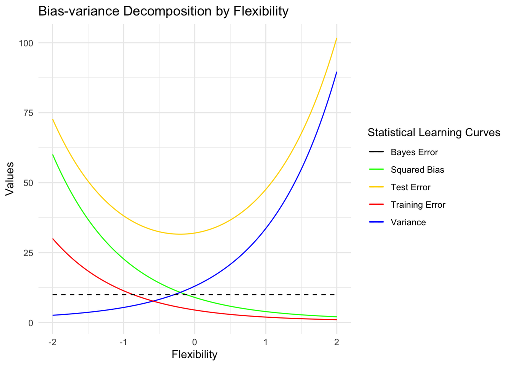

```r
library(ggplot2)
flexibility <- seq(-2, 2, length.out = 100)
squared_bias <- 8*exp(-flexibility) + 1
variance <- 12*exp(flexibility) + 1
training_error <- squared_bias*.5
irreducible_error <- 10
bayes_error <- irreducible_error
test_error <- squared_bias + variance + irreducible_error

ggplot() +
  geom_line(data = data.frame(flexibility, squared_bias), aes(x = flexibility, y = squared_bias, color = "Squared Bias")) +
  geom_line(data = data.frame(flexibility, variance), aes(x = flexibility, y = variance, color = "Variance")) +
  geom_line(data = data.frame(flexibility, training_error), aes(x = flexibility, y = training_error, color = "Training Error")) +
  geom_line(data = data.frame(flexibility, test_error), aes(x = flexibility, y = test_error, color = "Test Error")) +
  geom_line(data = data.frame(flexibility, bayes_error), aes(x = flexibility, y = bayes_error, color = "Bayes Error"), linetype = "dashed") +
  scale_color_manual(values = c("Squared Bias" = "green", "Variance" = "blue", "Training Error" = "red", "Test Error" = "gold", "Bayes Error" = "black")) +
  guides(color = guide_legend(title = "Statistical Learning Curves")) +
  labs(title = "Bias-variance Decomposition by Flexibility", x = "Flexibility", y = "Values") +
  theme_minimal()
```

### 2.2 2.4.3 (b)

**Answer:** - *Bias* refers to the error that is introduced by approximating a real-life problem, which may be extremely complicated, by a much simpler model. Bias is the difference between the expected (or average) prediction of our model and the correct value which we are trying to predict. Models with high bias pay very little attention to the training data and oversimplify the model. As a model becomes more flexible, the bias decreases.

## 3 ISL Exercise 2.4.4 (10pts)

You will now think of some real-life applications for statistical learning.

### 3.1 2.4.4 (a)

Describe three real-life applications in which classification might be useful. Describe the response, as well as the predictors. Is the goal of each application inference or prediction? Explain your answer.

**Answer:** 1. Predicting whether a patient has a disease or not based on their symptoms. The response is whether the patient has the disease or not, and the predictors are the symptoms. The goal of this application is prediction as we are trying to predict whether the patient has the disease or not based on their symptoms.

2. Predicting whether a student will pass or fail a class based on their grades. The response is whether the student will pass or fail the class, and the predictors are the grades. The goal of this application is prediction as we are trying to predict whether the student will pass or fail the class based on their grades.
3. Predicting whether a person will default on their loan based on their credit score. The response is whether the person will default on their loan or not, and the predictors are the credit score. The goal of this application is prediction as we are trying to predict whether the person will default on their loan based on their credit score.

### 3.2 2.4.4 (b)

Describe three real-life applications in which regression might be useful. Describe the response, as well as the predictors. Is the goal of each application inference or prediction? Explain your answer.

**Answer:** 1. Predicting the price of a house based on its features. The response is the price of the house, and the predictors are the features of the house. The goal of this application is prediction as we are trying to predict the price of the house based on its features.

2. Predicting the number of sales of a product based on its price. The response is the number of sales of the product, and the predictors are the price of the product. The goal of this application is prediction as we are trying to predict the number of sales of the product based on its price.
3. Predicting the number of people who will vote for a candidate based on their age. The response is the number of people who will vote for a candidate, and the predictors are the age of the people. The goal of this application is prediction as we are trying to predict the number of people who will vote for a candidate based on their age.

### 3.3 2.4.4 (c)

Describe three real-life applications in which cluster analysis might be useful.

**Answer:** 1. Grouping customers based on their shopping habits. The goal of this application is to group customers based on their shopping habits.

2. Grouping students based on their grades. The goal of this application is to group students based on their grades.
3. Grouping patients based on their symptoms. The goal of this application is to group patients based on their symptoms.

## 4 ISL Exercise 2.4.10 (30pts)

This exercise involves the Boston housing data set.

### 4.1 2.4.10 (a)

How many rows are in this data set? How many columns? What do the rows and columns represent?\

```r
library(tidyverse)

Boston <- read_csv("https://raw.githubusercontent.com/ucla-biostat-212a/2024winter/master/slides/data/Boston.csv", col_select = -1) %>%
  print(width = Inf)
```

```
# A tibble: 506 × 13
      crim    zn indus  chas   nox    rm   age   dis   rad   tax ptratio lstat
     <dbl> <dbl> <dbl> <dbl> <dbl> <dbl> <dbl> <dbl> <dbl> <dbl>   <dbl> <dbl>
 1 0.00632  18    2.31     0 0.538  6.58  65.2  4.09     1   296    15.3  4.98
 2 0.0273    0    7.07     0 0.469  6.42  78.9  4.97     2   242    17.8  9.14
 3 0.0273    0    7.07     0 0.469  7.18  61.1  4.97     2   242    17.8  4.03
 4 0.0324    0    2.18     0 0.458  7.00  45.8  6.06     3   222    18.7  2.94
 5 0.0690    0    2.18     0 0.458  7.15  54.2  6.06     3   222    18.7  5.33
 6 0.0298    0    2.18     0 0.458  6.43  58.7  6.06     3   222    18.7  5.21
 7 0.0883   12.5  7.87     0 0.524  6.01  66.6  5.56     5   311    15.2 12.4
 8 0.145    12.5  7.87     0 0.524  6.17  96.1  5.95     5   311    15.2 19.2
 9 0.211    12.5  7.87     0 0.524  5.63 100    6.08     5   311    15.2 29.9
10 0.170    12.5  7.87     0 0.524  6.00  85.9  6.59     5   311    15.2 17.1
    medv
   <dbl>
 1  24
 2  21.6
 3  34.7
 4  33.4
 5  36.2
 6  28.7
 7  22.9
 8  27.1
 9  16.5
10  18.9
# ℹ 496 more rows
```

```r
library(ISLR2)
Boston
```

```
# A tibble: 506 × 13
      crim    zn indus  chas   nox    rm   age   dis   rad   tax ptratio lstat
     <dbl> <dbl> <dbl> <dbl> <dbl> <dbl> <dbl> <dbl> <dbl> <dbl>   <dbl> <dbl>
 1 0.00632  18    2.31     0 0.538  6.58  65.2  4.09     1   296    15.3  4.98
 2 0.0273    0    7.07     0 0.469  6.42  78.9  4.97     2   242    17.8  9.14
 3 0.0273    0    7.07     0 0.469  7.18  61.1  4.97     2   242    17.8  4.03
 4 0.0324    0    2.18     0 0.458  7.00  45.8  6.06     3   222    18.7  2.94
 5 0.0690    0    2.18     0 0.458  7.15  54.2  6.06     3   222    18.7  5.33
 6 0.0298    0    2.18     0 0.458  6.43  58.7  6.06     3   222    18.7  5.21
 7 0.0883   12.5  7.87     0 0.524  6.01  66.6  5.56     5   311    15.2 12.4
 8 0.145    12.5  7.87     0 0.524  6.17  96.1  5.95     5   311    15.2 19.2
 9 0.211    12.5  7.87     0 0.524  5.63 100    6.08     5   311    15.2 29.9
10 0.170    12.5  7.87     0 0.524  6.00  85.9  6.59     5   311    15.2 17.1
# ℹ 496 more rows
# ℹ 1 more variable: medv <dbl>
```

```r
?Boston
```

**Answer:**\ There are 506 rows and 13 columns in this data set. The rows represent the different suburbs in Boston and the columns represent the different features of the suburbs.

### 4.2 2.4.10 (b)

Make some pairwise scatterplots of the predictors (columns) in this data set. Describe your findings.\ **Answer:** \

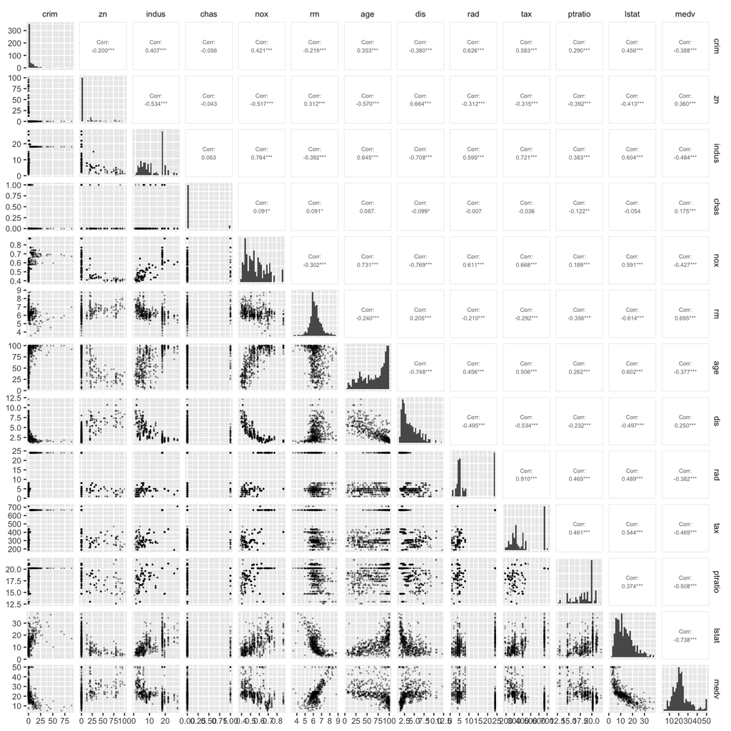

```r
library(GGally)
library(dplyr)
Boston %>% select(everything()) %>% ggpairs(lower = list(continuous = wrap("points", alpha = 0.3,    size=0.2)), diag=list(continuous='barDiag'), upper = list(continuous = wrap("cor", size = 2))) +
  theme(strip.background = element_blank(), strip.text = element_text(size = 8), axis.text = element_text(size = 8), axis.title = element_text(size = 9))
```

**Answer:**\ Industrial land has a strong positive correlation with nitrogen oxide concentrations (nox and indus), indicating that industrial activities are an important source of nitrogen oxide emissions. This insight could inform policymakers to implement stricter emission controls near industrial areas to mitigate environmental impacts.

The positive relationship between industrial land and tax rates (industrial and tax) may reflect the contribution of industrial land to local tax revenues or the government’s approach to imposing higher taxes on industrial properties to offset their environmental footprint.

Tax and rad: This positive relationship may indicate that areas with better transportation facilities, such as radial highways, tend to have higher property tax rates, perhaps because these areas are more popular or Have higher development potential.

There is a positive correlation between building age and nitrogen oxide concentration (building age and nitrogen oxide concentration), revealing the connection between old buildings and environmental quality, indicating the need for environmental improvements in areas with old buildings.

Distance to employment centers and nitrogen oxide concentrations (dis and nox): The negative correlation suggests that areas further from employment centers have lower nitrogen oxide levels, possibly due to reduced traffic and industrial activity.

Lower demographic status and median home value (lstat and medv): This strong negative relationship highlights the profound impact of socioeconomic factors on the housing market, suggesting that areas with concentrations of lower status populations tend to have lower Home value.

Asterisks indicate statistical significance, emphasizing the confidence in the correlation. For example, if there are three asterisks next to a correlation coefficient (usually indicating a p-value <0.001), this means there is a high degree of confidence that the relationship between the two variables is not due to chance. This statistical significance suggests that we can more certainly rely on these findings to inform policy or further research.

### 4.3 2.4.10 (c)

Are any of the predictors associated with per capita crime rate? If so, explain the relationship. **Answer:** There appears to be a positive relationship between industrial activity and crime rates. This may be due to factors such as lower income levels and reduced residential stability in areas with more industrial activity. Industrial areas often overlap with low-income neighborhoods, which may have higher crime rates.

There is a positive correlation between nitrogen oxide concentrations and crime rates. This shows that areas with higher levels of pollution are often uninhabitable and tend to have higher crime rates. Contaminated areas may overlap with industrial areas or low-income neighborhoods, which are more prone to crime.

There is a positive relationship between the proportion of the population with lower status and crime rates. Areas with lower income and education levels tend to have higher crime rates. This may be due to a range of socioeconomic factors, including limited access to resources and opportunities.

There is a negative relationship between the median number of owner-occupied homes and crime rates. This suggests that high-value homes are often located in areas with lower crime rates. Wealthy neighborhoods generally have better security, community resources, and lower socioeconomic stress, which helps lower crime rates.

Notably, although these associations exist, they appear to be relatively weak or low. This means other factors may also influence crime rates in these areas. These relationships provide a nuanced understanding of how different social, economic, and environmental factors interact to influence crime rates in different communities.

### 4.4 2.4.10 (d)

Do any of the census tracts of Boston appear to have particularly high crime rates? Tax rates? Pupil-teacher ratios? Comment on the range of each predictor. **Answer:**

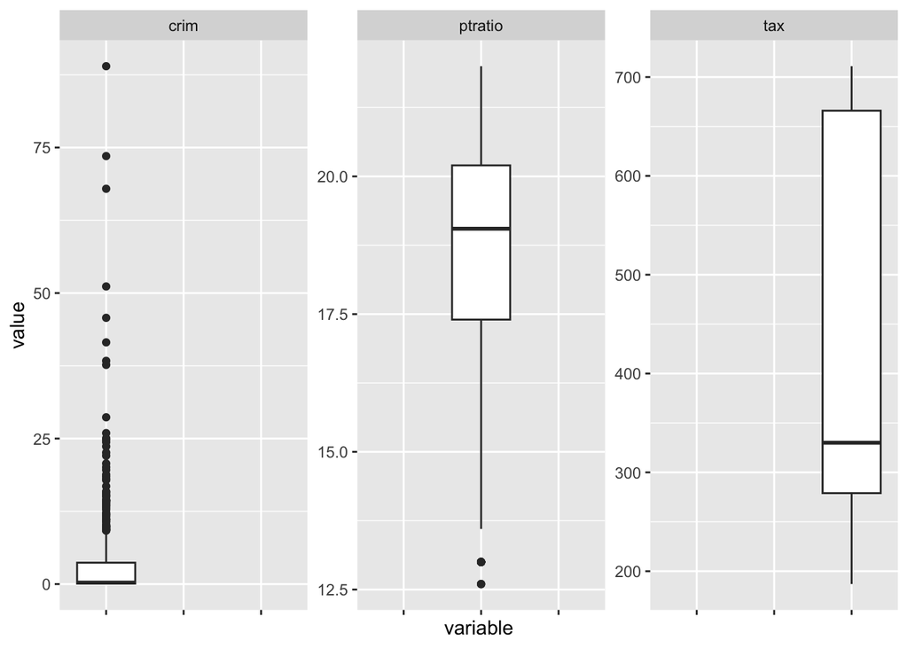

```r
Transpose_Boston <- Boston %>% pivot_longer(cols = c(crim, tax, ptratio), names_to = "variable", values_to = "value" )

ggplot(Transpose_Boston, aes(x = variable, y = value)) +
  geom_boxplot() +
  facet_wrap(~variable, scales = "free_y") +
  theme(axis.text.x = element_blank())
```

These charts give us a look at three different scenarios for Boston neighborhoods: crime rate, property tax rate, and number of students per teacher.

Looking at the crime rate (“crim”), the chart tells us that while most neighborhoods have low crime rates, there are a few that have very high crime rates. These high-crime areas are uncommon, but they contribute to the overall increase in crime.

Regarding the number of students per teacher (the “ratio”), the picture is fairly consistent across communities. As the lower numbers on the chart indicate, students in only a few communities are likely to receive more personal attention from teachers.

Essentially, Boston neighborhoods have the most variation in crime rates, with some areas experiencing particularly high crime rates. Tax rates also vary widely, but not as extreme as on crime. Student-to-teacher ratios are largely consistent, suggesting consistent school staffing levels across districts.

### 4.5 2.4.10 (e)

How many of the census tracts in this data set bound the Charles river?

```r
table(Boston$chas)
```

```
  0   1
471  35
```

**Answer:** There are 35 census tracts in this data set bound the Charles river. The categorical variable ‘chas’ is composed of binary values where ‘O’ represents tracts that do not border the Charles River and ‘1’ represents tracts that do border the Charles River.

### 4.6 2.4.10 (f)

What is the median pupil-teacher ratio among the towns in this data set?

```r
median(Boston$ptratio)
```

```
[1] 19.05
```

**Answer:** The median pupil-teacher ratio among the towns in this data set is 19.05.

### 4.7 2.4.10 (g)

Which census tract of Boston has lowest median value of owner- occupied homes? What are the values of the other predictors for that census tract, and how do those values compare to the overall ranges for those predictors? Comment on your findings.

```r
Bostonobs <- data.frame("obs"=1:nrow(Boston), Boston)
Bostonobs %>% filter(medv == min(medv))
```

```
  obs    crim zn indus chas   nox    rm age    dis rad tax ptratio lstat medv
1 399 38.3518  0  18.1    0 0.693 5.453 100 1.4896  24 666    20.2 30.59    5
2 406 67.9208  0  18.1    0 0.693 5.683 100 1.4254  24 666    20.2 22.98    5
```

```r
summary(Bostonobs[,2:14])
```

```
      crim                zn             indus            chas
 Min.   : 0.00632   Min.   :  0.00   Min.   : 0.46   Min.   :0.00000
 1st Qu.: 0.08205   1st Qu.:  0.00   1st Qu.: 5.19   1st Qu.:0.00000
 Median : 0.25651   Median :  0.00   Median : 9.69   Median :0.00000
 Mean   : 3.61352   Mean   : 11.36   Mean   :11.14   Mean   :0.06917
 3rd Qu.: 3.67708   3rd Qu.: 12.50   3rd Qu.:18.10   3rd Qu.:0.00000
 Max.   :88.97620   Max.   :100.00   Max.   :27.74   Max.   :1.00000
      nox               rm             age              dis
 Min.   :0.3850   Min.   :3.561   Min.   :  2.90   Min.   : 1.130
 1st Qu.:0.4490   1st Qu.:5.886   1st Qu.: 45.02   1st Qu.: 2.100
 Median :0.5380   Median :6.208   Median : 77.50   Median : 3.207
 Mean   :0.5547   Mean   :6.285   Mean   : 68.57   Mean   : 3.795
 3rd Qu.:0.6240   3rd Qu.:6.623   3rd Qu.: 94.08   3rd Qu.: 5.188
 Max.   :0.8710   Max.   :8.780   Max.   :100.00   Max.   :12.127
      rad              tax           ptratio          lstat
 Min.   : 1.000   Min.   :187.0   Min.   :12.60   Min.   : 1.73
 1st Qu.: 4.000   1st Qu.:279.0   1st Qu.:17.40   1st Qu.: 6.95
 Median : 5.000   Median :330.0   Median :19.05   Median :11.36
 Mean   : 9.549   Mean   :408.2   Mean   :18.46   Mean   :12.65
 3rd Qu.:24.000   3rd Qu.:666.0   3rd Qu.:20.20   3rd Qu.:16.95
 Max.   :24.000   Max.   :711.0   Max.   :22.00   Max.   :37.97
      medv
 Min.   : 5.00
 1st Qu.:17.02
 Median :21.20
 Mean   :22.53
 3rd Qu.:25.00
 Max.   :50.00
```

### 4.8 2.4.10 (h)

In this data set, how many of the census tracts average more than seven rooms per dwelling? More than eight rooms per dwelling? Comment on the census tracts that average more than eight rooms per dwelling.

```r
seven_rooms <- Bostonobs %>% filter(rm > 7)
eight_rooms <- Bostonobs %>% filter(rm > 8)
data.frame("seven_rooms_more" = nrow(seven_rooms), "eight_rooms_more" = nrow(eight_rooms))
```

```
  seven_rooms_more eight_rooms_more
1               64               13
```

```r
summary(seven_rooms)
```

```
      obs             crim                zn            indus
 Min.   :  3.0   Min.   : 0.00906   Min.   : 0.00   Min.   : 0.460
 1st Qu.:186.0   1st Qu.: 0.04502   1st Qu.: 0.00   1st Qu.: 2.460
 Median :230.5   Median : 0.09786   Median :20.00   Median : 3.970
 Mean   :224.0   Mean   : 0.97911   Mean   :28.17   Mean   : 5.776
 3rd Qu.:270.2   3rd Qu.: 0.54289   3rd Qu.:45.00   3rd Qu.: 6.200
 Max.   :483.0   Max.   :19.60910   Max.   :95.00   Max.   :19.580
      chas            nox               rm             age
 Min.   :0.000   Min.   :0.3940   Min.   :7.007   Min.   :  8.40
 1st Qu.:0.000   1st Qu.:0.4303   1st Qu.:7.183   1st Qu.: 36.00
 Median :0.000   Median :0.4880   Median :7.414   Median : 63.80
 Mean   :0.125   Mean   :0.5045   Mean   :7.570   Mean   : 60.64
 3rd Qu.:0.000   3rd Qu.:0.5825   3rd Qu.:7.859   3rd Qu.: 85.03
 Max.   :1.000   Max.   :0.7180   Max.   :8.780   Max.   :100.00
      dis             rad              tax           ptratio
 Min.   :1.202   Min.   : 1.000   Min.   :193.0   Min.   :12.60
 1st Qu.:2.445   1st Qu.: 3.000   1st Qu.:244.8   1st Qu.:14.70
 Median :3.495   Median : 5.000   Median :273.0   Median :17.40
 Mean   :4.200   Mean   : 5.984   Mean   :312.2   Mean   :16.26
 3rd Qu.:5.463   3rd Qu.: 7.000   3rd Qu.:329.0   3rd Qu.:17.93
 Max.   :9.223   Max.   :24.000   Max.   :666.0   Max.   :20.20
     lstat             medv
 Min.   : 1.730   Min.   :15.00
 1st Qu.: 3.555   1st Qu.:32.98
 Median : 4.775   Median :36.45
 Mean   : 5.474   Mean   :38.40
 3rd Qu.: 6.590   3rd Qu.:46.17
 Max.   :16.740   Max.   :50.00
```

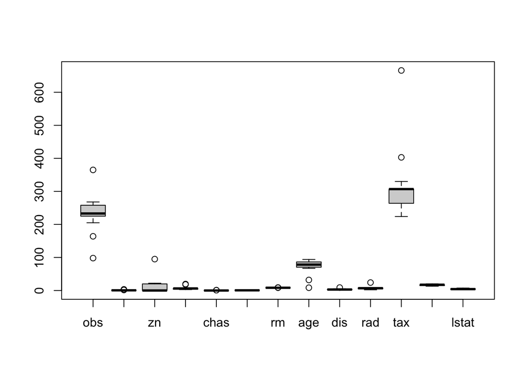

```r
boxplot(eight_rooms[,1:13])
```

**Answer:** In the provided data set, there are 64 census tracts where homes average more than seven rooms, and 13 census tracts where homes average more than eight rooms. Areas with larger homes have lower crime rates and student-teacher ratios, meaning a safer and more supportive educational environment. These areas typically enjoy lower tax rates, are primarily residential, have less commercial development, are located further away from highways, and are often made up of older, possibly historic homes, indicating quieter and possibly more affluent neighborhoods.

## 5 ISL Exercise 3.7.3 (12pts)

Suppose we have a data set with five predictors, X1 = GPA, X2 = IQ, X3 = Level (1 for College and 0 for High School), X4 = Interac- tion between GPA and IQ, and X5 = Interaction between GPA and Level. The response is starting salary after graduation (in thousands of dollars). Suppose we use least squares to fit the model, and get βˆ0 = 50,βˆ1 = 20,βˆ2 = 0.07,βˆ3 = 35,βˆ4 = 0.01,βˆ5 = −10. ### 3.7.3 (a) Which answer is correct, and why? i. For a fixed value of IQ and GPA, high school graduates earn more, on average, than college graduates. ii. For a fixed value of IQ and GPA, college graduates earn more, on average, than high school graduates. iii. For a fixed value of IQ and GPA, high school graduates earn more, on average, than college graduates provided that the GPA is high enough. iv. For a fixed value of IQ and GPA, college graduates earn more, on average, than high school graduates provided that the GPA is high enough.

### 5.1 3.7.3 (b)

Predict the salary of a college graduate with IQ of 110 and a GPA of 4.0. **Answer:**
$$\begin{align}
Salary(college) &= 50 + 20X_1 + 0.07X_2 + 35 + 0.01(X_1X_2) - 10X_1 \\
&= 50 + 20(4) + 0.07(110) + 35 + 0.01(4*110) - 10(4) \\
&= 137.1 \\
\end{align}$$

### 5.2 3.7.3 (c)

True or false: Since the coefficient for the GPA/IQ interaction term is very small, there is very little evidence of an interaction effect. Justify your answer.

**Answer:** False. The coefficient size is not a good indicator of the importance of a predictor in a model, it does not imply statistical significance.

## 6 ISL Exercise 3.7.15 (20pts)

This problem involves the Boston data set, which we saw in the lab for this chapter. We will now try to predict per capita crime rate using the other variables in this data set. In other words, per capita crime rate is the response, and the other variables are the predictors.

### 6.1 3.7.15 (a)

For each predictor, fit a simple linear regression model to predict the response. Describe your results. In which of the models is there a statistically significant association between the predictor and the response? Create some plots to back up your assertions.

```r
output <- data.frame()
for (predictor in colnames(Boston)[2:13]) {
  all_sum <- summary(lm(formula=paste("crim ~ ",predictor), data = Boston))
  coeffocoent_table <- all_sum$coefficients
  #need to organize the info
  intercept_coeff <- coeffocoent_table[1,]
  predictor_coeff <- coeffocoent_table[2,]
  rsquared <- all_sum$r.squared
  adj_rsquared <- all_sum$adj.r.squared

  newBoston <- data.frame(
    "predictor" = predictor,
    intercept = round(intercept_coeff["Estimate"], 3),
    beta = round(predictor_coeff["Estimate"], 3),
    std_error = round(predictor_coeff["Std. Error"], 3),
    t_value = round(predictor_coeff["t value"], 3),
    p_value = round(predictor_coeff["Pr(>|t|)"], 3),
    rsquared = round(rsquared, 3),
    adj_rsquared = round(adj_rsquared, 3)
    )
  output <- rbind(output, newBoston)
}
print(output)
```

```
           predictor intercept   beta std_error t_value p_value rsquared
Estimate          zn     4.454 -0.074     0.016  -4.594   0.000    0.040
Estimate1      indus    -2.064  0.510     0.051   9.991   0.000    0.165
Estimate2       chas     3.744 -1.893     1.506  -1.257   0.209    0.003
Estimate3        nox   -13.720 31.249     2.999  10.419   0.000    0.177
Estimate4         rm    20.482 -2.684     0.532  -5.045   0.000    0.048
Estimate5        age    -3.778  0.108     0.013   8.463   0.000    0.124
Estimate6        dis     9.499 -1.551     0.168  -9.213   0.000    0.144
Estimate7        rad    -2.287  0.618     0.034  17.998   0.000    0.391
Estimate8        tax    -8.528  0.030     0.002  16.099   0.000    0.340
Estimate9    ptratio   -17.647  1.152     0.169   6.801   0.000    0.084
Estimate10     lstat    -3.331  0.549     0.048  11.491   0.000    0.208
Estimate11      medv    11.797 -0.363     0.038  -9.460   0.000    0.151
           adj_rsquared
Estimate          0.038
Estimate1         0.164
Estimate2         0.001
Estimate3         0.176
Estimate4         0.046
Estimate5         0.123
Estimate6         0.142
Estimate7         0.390
Estimate8         0.338
Estimate9         0.082
Estimate10        0.206
Estimate11        0.149
```

### 6.2 3.7.15 (b)

Fit a multiple regression model to predict the response using all of the predictors. Describe your results. For which predictors can we reject the null hypothesis H0 : βj = 0?

[figure not shown]

```r
long_Boston <- Boston %>%
  pivot_longer(
    cols = c('rad', 'tax', 'nox', 'chas'),
    names_to = "predictor",
    values_to = "value")

ggplot(long_Boston, aes(x = value, y = crim)) +
  geom_point(alpha = 0.5) +
  facet_wrap(~predictor, scales = "free") +
  geom_smooth(method = "lm", color = "blue", se = FALSE) +
  theme_bw() +
  theme(legend.position = "none")
```

### 6.3 3.7.15 (c)

How do your results from (a) compare to your results from (b)? Create a plot displaying the univariate regression coefficients from (a) on the x-axis, and the multiple regression coefficients from (b) on the y-axis. That is, each predictor is displayed as a single point in the plot. Its coefficient in a simple linear regres- sion model is shown on the x-axis, and its coefficient estimate in the multiple linear regression model is shown on the y-axis.

```r
data.frame(
  "predictor" = colnames(Boston)[2:13],
  "simple_regression" = output$beta,
  "multiple_regression" = summary(lm(crim ~ ., data = Boston))$coefficients[-1,1]
)
```

```
        predictor simple_regression multiple_regression
zn             zn            -0.074        0.0457100386
indus       indus             0.510       -0.0583501107
chas         chas            -1.893       -0.8253775522
nox           nox            31.249       -9.9575865471
rm             rm            -2.684        0.6289106622
age           age             0.108       -0.0008482791
dis           dis            -1.551       -1.0122467382
rad           rad             0.618        0.6124653115
tax           tax             0.030       -0.0037756465
ptratio   ptratio             1.152       -0.3040727572
lstat       lstat             0.549        0.1388005968
medv         medv            -0.363       -0.2200563590
```

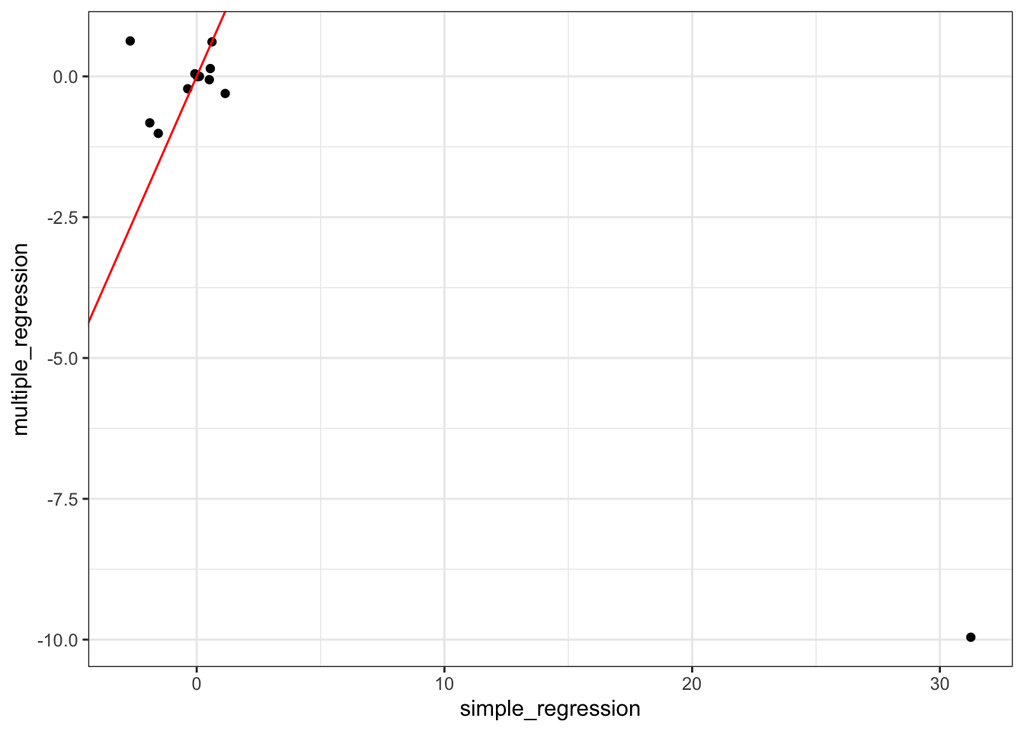

```r
ggplot(data.frame(
  "predictor" = colnames(Boston)[2:13],
  "simple_regression" = output$beta,
  "multiple_regression" = summary(lm(crim ~ ., data = Boston))$coefficients[-1,1]
), aes(x = simple_regression, y = multiple_regression)) +
  geom_point() +
  geom_abline(intercept = 0, slope = 1, color = "red") +
  theme_bw()
```

**Answer:** When comparing the simple linear regression model (a) and the multiple regression model (b), clear differences emerge in the estimated impact of each predictor on crime rates. It is worth noting that the “nitrogen oxides” variable measuring air pollution levels has a large positive coefficient in the simple regression, but becomes negative in the multiple regression. This shows that when NOx is considered alone, it appears to be associated with higher crime rates, but when other factors are also considered, its relationship with crime is reversed.

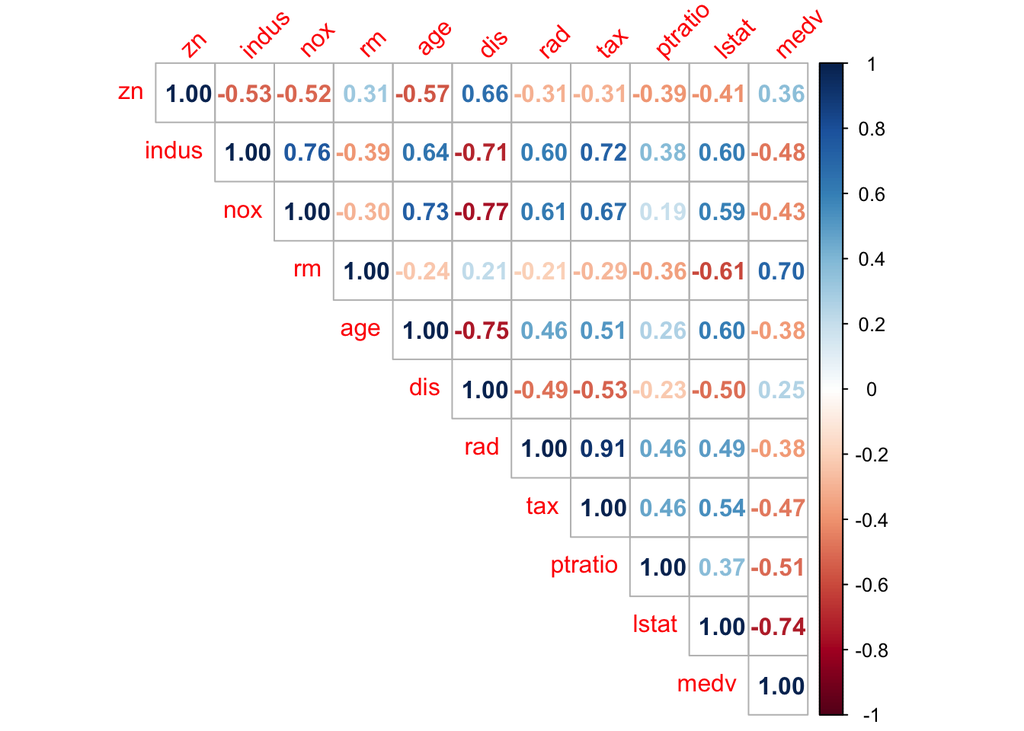

```r
library(corrplot)
hearplot <- round(cor(Boston[-c(1,4)]), 2)
corrplot(hearplot, method = "number", type = "upper", tl.srt = 45)
```

**Answer:** A graph comparing the two sets of coefficients shows that while some predictors, such as “nitrogen oxides,” change dramatically when moving from a univariate to a multivariate environment, other predictors change little, indicating that regardless of which model is used, The impact is consistent. This means that, when considered together, some predictors may have intercorrelations that influence their individual effects on responses. The plot visually represents each predictor as a point with its simple regression effect on the x-axis and its multiple regression effect on the y-axis, illustrating the differences in these effects.

### 6.4 3.7.15 (d)

Is there evidence of non-linear association between any of the predictors and the response? To answer this question, for each predictor X, fit a model of the form
$$Y = β_0 + β_1X + β_2X_2 + β_3X_3 + ε.$$
1. zn

```r
summary(lm(crim ~ poly(zn, 3), data = Boston))
```

```
Call:
lm(formula = crim ~ poly(zn, 3), data = Boston)

Residuals:
   Min     1Q Median     3Q    Max
-4.821 -4.614 -1.294  0.473 84.130

Coefficients:
             Estimate Std. Error t value Pr(>|t|)
(Intercept)    3.6135     0.3722   9.709  < 2e-16 ***
poly(zn, 3)1 -38.7498     8.3722  -4.628  4.7e-06 ***
poly(zn, 3)2  23.9398     8.3722   2.859  0.00442 **
poly(zn, 3)3 -10.0719     8.3722  -1.203  0.22954
---
Signif. codes:  0 '***' 0.001 '**' 0.01 '*' 0.05 '.' 0.1 ' ' 1

Residual standard error: 8.372 on 502 degrees of freedom
Multiple R-squared:  0.05824,   Adjusted R-squared:  0.05261
F-statistic: 10.35 on 3 and 502 DF,  p-value: 1.281e-06
```

**Answer:** For the predictor ‘zn’ the cubic coefficient is not statistically significant, however the quadratic is, which could imply that there is a non-linear relationship between the predictor and the response at the quadratic level.

2. indus

```r
summary(lm(crim ~ poly(indus, 3), data = Boston))
```

```
Call:
lm(formula = crim ~ poly(indus, 3), data = Boston)

Residuals:
   Min     1Q Median     3Q    Max
-8.278 -2.514  0.054  0.764 79.713

Coefficients:
                Estimate Std. Error t value Pr(>|t|)
(Intercept)        3.614      0.330  10.950  < 2e-16 ***
poly(indus, 3)1   78.591      7.423  10.587  < 2e-16 ***
poly(indus, 3)2  -24.395      7.423  -3.286  0.00109 **
poly(indus, 3)3  -54.130      7.423  -7.292  1.2e-12 ***
---
Signif. codes:  0 '***' 0.001 '**' 0.01 '*' 0.05 '.' 0.1 ' ' 1

Residual standard error: 7.423 on 502 degrees of freedom
Multiple R-squared:  0.2597,    Adjusted R-squared:  0.2552
F-statistic: 58.69 on 3 and 502 DF,  p-value: < 2.2e-16
```

**Answer:** All of the polynomial valugs for ‘indus’ are statistically significant and so this would imply that there is a non-linear relationship between the predictor and the response.

3. nox

```r
summary(lm(crim ~ poly(nox, 3), data = Boston))
```

```
Call:
lm(formula = crim ~ poly(nox, 3), data = Boston)

Residuals:
   Min     1Q Median     3Q    Max
-9.110 -2.068 -0.255  0.739 78.302

Coefficients:
              Estimate Std. Error t value Pr(>|t|)
(Intercept)     3.6135     0.3216  11.237  < 2e-16 ***
poly(nox, 3)1  81.3720     7.2336  11.249  < 2e-16 ***
poly(nox, 3)2 -28.8286     7.2336  -3.985 7.74e-05 ***
poly(nox, 3)3 -60.3619     7.2336  -8.345 6.96e-16 ***
---
Signif. codes:  0 '***' 0.001 '**' 0.01 '*' 0.05 '.' 0.1 ' ' 1

Residual standard error: 7.234 on 502 degrees of freedom
Multiple R-squared:  0.297, Adjusted R-squared:  0.2928
F-statistic: 70.69 on 3 and 502 DF,  p-value: < 2.2e-16
```

4. rm

```r
summary(lm(crim ~ poly(rm, 3), data = Boston))
```

```
Call:
lm(formula = crim ~ poly(rm, 3), data = Boston)

Residuals:
    Min      1Q  Median      3Q     Max
-18.485  -3.468  -2.221  -0.015  87.219

Coefficients:
             Estimate Std. Error t value Pr(>|t|)
(Intercept)    3.6135     0.3703   9.758  < 2e-16 ***
poly(rm, 3)1 -42.3794     8.3297  -5.088 5.13e-07 ***
poly(rm, 3)2  26.5768     8.3297   3.191  0.00151 **
poly(rm, 3)3  -5.5103     8.3297  -0.662  0.50858
---
Signif. codes:  0 '***' 0.001 '**' 0.01 '*' 0.05 '.' 0.1 ' ' 1

Residual standard error: 8.33 on 502 degrees of freedom
Multiple R-squared:  0.06779,   Adjusted R-squared:  0.06222
F-statistic: 12.17 on 3 and 502 DF,  p-value: 1.067e-07
```

**Answer:** For the predictor ‘rm’ the cubic coefficient is not statistically significant, however the quadratic is, which could imply that there is a non-linear relationship between the predictor and the response at the quadratic level.

5. age

```r
summary(lm(crim ~ poly(age, 3), data = Boston))
```

```
Call:
lm(formula = crim ~ poly(age, 3), data = Boston)

Residuals:
   Min     1Q Median     3Q    Max
-9.762 -2.673 -0.516  0.019 82.842

Coefficients:
              Estimate Std. Error t value Pr(>|t|)
(Intercept)     3.6135     0.3485  10.368  < 2e-16 ***
poly(age, 3)1  68.1820     7.8397   8.697  < 2e-16 ***
poly(age, 3)2  37.4845     7.8397   4.781 2.29e-06 ***
poly(age, 3)3  21.3532     7.8397   2.724  0.00668 **
---
Signif. codes:  0 '***' 0.001 '**' 0.01 '*' 0.05 '.' 0.1 ' ' 1

Residual standard error: 7.84 on 502 degrees of freedom
Multiple R-squared:  0.1742,    Adjusted R-squared:  0.1693
F-statistic: 35.31 on 3 and 502 DF,  p-value: < 2.2e-16
```

**Answer:** All of the polynomial values for ‘age’ are statistically significant and so this would imply that there is a non-linear relationship between the predictor and the response at all levels.

6. dis

```r
summary(lm(crim ~ poly(dis, 3), data = Boston))
```

```
Call:
lm(formula = crim ~ poly(dis, 3), data = Boston)

Residuals:
    Min      1Q  Median      3Q     Max
-10.757  -2.588   0.031   1.267  76.378

Coefficients:
              Estimate Std. Error t value Pr(>|t|)
(Intercept)     3.6135     0.3259  11.087  < 2e-16 ***
poly(dis, 3)1 -73.3886     7.3315 -10.010  < 2e-16 ***
poly(dis, 3)2  56.3730     7.3315   7.689 7.87e-14 ***
poly(dis, 3)3 -42.6219     7.3315  -5.814 1.09e-08 ***
---
Signif. codes:  0 '***' 0.001 '**' 0.01 '*' 0.05 '.' 0.1 ' ' 1

Residual standard error: 7.331 on 502 degrees of freedom
Multiple R-squared:  0.2778,    Adjusted R-squared:  0.2735
F-statistic: 64.37 on 3 and 502 DF,  p-value: < 2.2e-16
```

7. rad

```r
summary(lm(crim ~ poly(rad, 3), data = Boston))
```

```
Call:
lm(formula = crim ~ poly(rad, 3), data = Boston)

Residuals:
    Min      1Q  Median      3Q     Max
-10.381  -0.412  -0.269   0.179  76.217

Coefficients:
              Estimate Std. Error t value Pr(>|t|)
(Intercept)     3.6135     0.2971  12.164  < 2e-16 ***
poly(rad, 3)1 120.9074     6.6824  18.093  < 2e-16 ***
poly(rad, 3)2  17.4923     6.6824   2.618  0.00912 **
poly(rad, 3)3   4.6985     6.6824   0.703  0.48231
---
Signif. codes:  0 '***' 0.001 '**' 0.01 '*' 0.05 '.' 0.1 ' ' 1

Residual standard error: 6.682 on 502 degrees of freedom
Multiple R-squared:    0.4, Adjusted R-squared:  0.3965
F-statistic: 111.6 on 3 and 502 DF,  p-value: < 2.2e-16
```

**Answer:** For the predictor ‘rad’ the cubic coefficient is not statistically significant, however the quadratic is, which could imply that there is a non-linear relationship between the predictor and the response at the quadratic level.

8. tax

```r
summary(lm(crim ~ poly(tax, 3), data = Boston))
```

```
Call:
lm(formula = crim ~ poly(tax, 3), data = Boston)

Residuals:
    Min      1Q  Median      3Q     Max
-13.273  -1.389   0.046   0.536  76.950

Coefficients:
              Estimate Std. Error t value Pr(>|t|)
(Intercept)     3.6135     0.3047  11.860  < 2e-16 ***
poly(tax, 3)1 112.6458     6.8537  16.436  < 2e-16 ***
poly(tax, 3)2  32.0873     6.8537   4.682 3.67e-06 ***
poly(tax, 3)3  -7.9968     6.8537  -1.167    0.244
---
Signif. codes:  0 '***' 0.001 '**' 0.01 '*' 0.05 '.' 0.1 ' ' 1

Residual standard error: 6.854 on 502 degrees of freedom
Multiple R-squared:  0.3689,    Adjusted R-squared:  0.3651
F-statistic:  97.8 on 3 and 502 DF,  p-value: < 2.2e-16
```

**Answer:** For the predictor ‘tax’ the cubic coefficient is not statistically significant, however the quadratic is, which could imply that there is a non-linear relationship between the predictor and the response at the quadratic level.

9.ptratio

```r
summary(lm(crim ~ poly(ptratio, 3), data = Boston))
```

```
Call:
lm(formula = crim ~ poly(ptratio, 3), data = Boston)

Residuals:
   Min     1Q Median     3Q    Max
-6.833 -4.146 -1.655  1.408 82.697

Coefficients:
                  Estimate Std. Error t value Pr(>|t|)
(Intercept)          3.614      0.361  10.008  < 2e-16 ***
poly(ptratio, 3)1   56.045      8.122   6.901 1.57e-11 ***
poly(ptratio, 3)2   24.775      8.122   3.050  0.00241 **
poly(ptratio, 3)3  -22.280      8.122  -2.743  0.00630 **
---
Signif. codes:  0 '***' 0.001 '**' 0.01 '*' 0.05 '.' 0.1 ' ' 1

Residual standard error: 8.122 on 502 degrees of freedom
Multiple R-squared:  0.1138,    Adjusted R-squared:  0.1085
F-statistic: 21.48 on 3 and 502 DF,  p-value: 4.171e-13
```

10. lstat

```r
summary(lm(crim ~ poly(lstat, 3), data = Boston))
```

```
Call:
lm(formula = crim ~ poly(lstat, 3), data = Boston)

Residuals:
    Min      1Q  Median      3Q     Max
-15.234  -2.151  -0.486   0.066  83.353

Coefficients:
                Estimate Std. Error t value Pr(>|t|)
(Intercept)       3.6135     0.3392  10.654   <2e-16 ***
poly(lstat, 3)1  88.0697     7.6294  11.543   <2e-16 ***
poly(lstat, 3)2  15.8882     7.6294   2.082   0.0378 *
poly(lstat, 3)3 -11.5740     7.6294  -1.517   0.1299
---
Signif. codes:  0 '***' 0.001 '**' 0.01 '*' 0.05 '.' 0.1 ' ' 1

Residual standard error: 7.629 on 502 degrees of freedom
Multiple R-squared:  0.2179,    Adjusted R-squared:  0.2133
F-statistic: 46.63 on 3 and 502 DF,  p-value: < 2.2e-16
```

11. medv

```r
summary(lm(crim ~ poly(medv, 3), data = Boston))
```

```
Call:
lm(formula = crim ~ poly(medv, 3), data = Boston)

Residuals:
    Min      1Q  Median      3Q     Max
-24.427  -1.976  -0.437   0.439  73.655

Coefficients:
               Estimate Std. Error t value Pr(>|t|)
(Intercept)       3.614      0.292  12.374  < 2e-16 ***
poly(medv, 3)1  -75.058      6.569 -11.426  < 2e-16 ***
poly(medv, 3)2   88.086      6.569  13.409  < 2e-16 ***
poly(medv, 3)3  -48.033      6.569  -7.312 1.05e-12 ***
---
Signif. codes:  0 '***' 0.001 '**' 0.01 '*' 0.05 '.' 0.1 ' ' 1

Residual standard error: 6.569 on 502 degrees of freedom
Multiple R-squared:  0.4202,    Adjusted R-squared:  0.4167
F-statistic: 121.3 on 3 and 502 DF,  p-value: < 2.2e-16
```

**Answer:** All of the polynomial values for ‘medv’ are statistically significant and so this would imply that there is a non-linear relationship between the predictor and the response at all levels.

## 7 Bonus question (20pts)

For multiple linear regression, show that $R^2$ is equal to the correlation between the response vector $\mathbf{y} = (y_1, \ldots, y_n)^T$ and the fitted values $\hat{\mathbf{y}} = (\hat y_1, \ldots, \hat y_n)^T$.

### 7.1 Answer 1:

$$R^2 = 1 - \frac{\text{RSS}}{\text{TSS}} = [\operatorname{Cor}(\mathbf{y}, \hat{\mathbf{y}})]^2.$$

$$\begin{align}
\text{Cor}(x, y) \\
&= \frac{\sum_{i} (x_i - \bar{x})(y_i - \bar{y})}
{\sqrt{\sum_{i} (x_i - \bar{x})^2 \sum_{i} (y_i - \bar{y})^2}} \\
&= \frac{(\mathbf{x} - \frac{1}{n}\mathbf{J}\bar{x})^T(\mathbf{y} - \frac{1}{n}\mathbf{J}\bar{y})}
{\sqrt{(\mathbf{x} - \frac{1}{n}\mathbf{J}\bar{x})^T(\mathbf{x} - \frac{1}{n}\mathbf{J}\bar{x}) (\mathbf{y} - \frac{1}{n}\mathbf{J}\bar{y})^T(\mathbf{y} - \frac{1}{n}\mathbf{J}\bar{y})}}
\end{align}$$
Where J is a matrix of ones and $\bar{x}$ is the mean of x.

Finally we have
$$\text{Cor}(Y, \hat{Y})^2 = \frac{(Y - \frac{J}{n}JY)^T(Y - \frac{J}{n}J\hat{Y})}{\left[(Y - \frac{J}{n}JY)^T(Y - \frac{J}{n}JY)\right]\left[(\hat{Y} - \frac{J}{n}J\hat{Y})^T(\hat{Y} - \frac{J}{n}J\hat{Y})\right]}$$
where
$$\hat{Y} = X(X^TX)^{-1}X^TY = HY$$

### 7.2 Answer 2:

$$\begin{align}
R^2
&= 1 - \frac{\text{RSS}}{\text{TSS}} \\
&= \frac{\text{TSS}-\text{RSS}}{\text{TSS}} \\
&= \frac{\text{ESS}}{\text{TSS}}\\
\end{align}$$
Since $\hat y_i = \hat{\beta}_0 + \hat{\beta}_1 x_{i1} + \ldots + \hat{\beta}_p x_{ip}$, we have
$$\text{RSS} = \sum_{i=1}^n (y_i - \hat y_i)^2\\
\text{ESS} = \sum_{i=1}^n (\hat y_i - \bar{\hat y})^2\\
\text{TSS} = \sum_{i=1}^n (y_i - \bar y)^2 \\$$
Hence,
$$\begin{align}
\frac{\text{ESS}}{\text{TSS}} \\
&= \frac{\sum_{i=1}^n (\hat y_i - \bar y)^2}{\sum_{i=1}^n (y_i - \bar y)^2} \\
&= \frac{\sum_{i=1}^n (\hat y_i - \bar y)^2 \sum_{i=1}^n(\hat y_i - \bar{\hat y})^2}{\sum_{i=1}^n (y_i - \bar y)^2 \sum_{i=1}^n(\hat y_i - \bar{\hat y})^2} \\
&= \frac{[\sum_{i=1}^n (y_i - \bar y)(\hat y_i - \bar{\hat y})]^2}{[\sum_{i=1}^n (y_i - \bar y)^2][\sum_{i=1}^n(\hat y_i - \bar{\hat y})^2]} \\
&= [\frac{\operatorname{Cor}(\mathbf{y_i}, \hat{\mathbf{y_i}})}{\sqrt(\operatorname{Var(y_i)}\sqrt(\operatorname{Var(\hat y_i)}) }]^2 \\
&= [\operatorname{Cor}(\mathbf{y}, \hat{\mathbf{y}})]^2.
\end{align}$$